←

# **MY DOCUMENTATION SYSTEM**

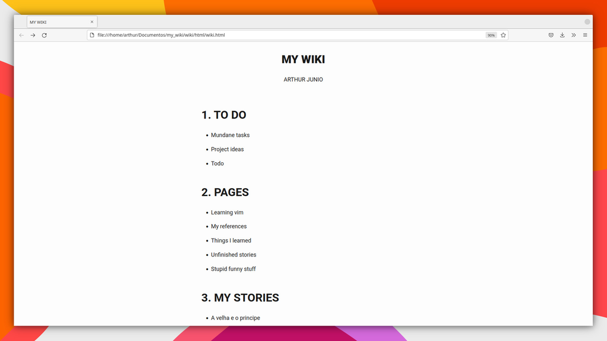

A wiki documentation system made using *GNU Make* and *Pandoc* that integrates with the operating system for quick note-taking

# Overview

I always had trouble with organizing files in my computer, especially when it comes to text files and notes, so I decided to try a few organization systems and applications like *Emacs Org Mode*, *Vim Wiki* and others, but I didn’t quite adapt to these systems, as they offered too many functions that I don’t need, so I decided to create my own simple wiki using nothing but a makefile and *Pandoc* (and also a custom binary I wrote in C++ used to generate the main wiki file.)

# How it works

The wiki is composed of sections, which contain pages, each section is a directory inside the `pages` directory and each page is a markdown file in any section directory.

A makefile uses a parser to to build the html (or pdf) output. The parser manipulates the filenames to create the main wiki page.

- pages
  - to_do
    - supermarket_stuf.md
    - project_ideas.md
  - my_creepy_stories
    - the_old_house.md
    - the_killer_pencil_from_outer_space.md

# The parser

To avoid a series of `sed` operations, I decided to do the parsing and text manipulation in a separate script, but since this little system had the purpose of testing interesting things, I decided to create a C++ program to test the `std::filesystem`, from C++17. (Python would be more appropriate).

The parser receives the filenames and outputs the edited text to standard output in the form of a markdown link *[Filename](path/to/filename)*

# The makefile

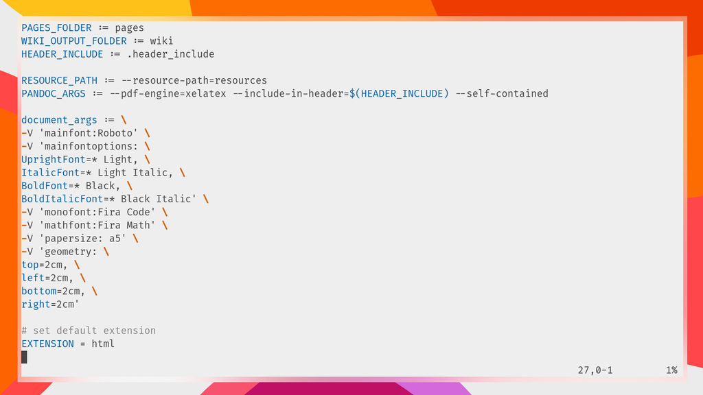

# Operating System Integration

[video not shown]

There’s a `.wiki_alias` file, which is a bash script that creates some aliases and is run in the `.bashrc` file. This way it’s possible to quickly access and edit a task, page, project idea, etc.

# The output

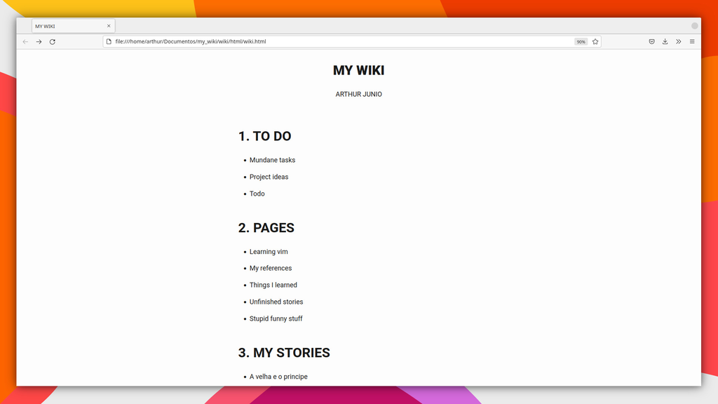

The output is a new directory `wiki`, which contains the html (and pdf) with all of the working links.

Page design by [*Arthur Junio*](http://OvercookedRoach.github.io)